# 🤨 Relembrando

- O intervalo de confiança mostra todos os valores plausíveis para o parâmetro.
- O teste de hipótese mede a probabilidade de observar os dados se H0 fosse verdadeira.

# 🎯 Relação entre Intervalo de Confiança e Testes de Significância

- Se o intervalo de confiança de 95% NÃO contém o valor de interesse (ex: 0 para diferença de médias, 1 para risco relativo) → o teste será estatisticamente significativo (valor-p < 0,05).
- Se o intervalo de confiança de 95% CONTÉM o valor de interesse → o teste será não significativo (valor-p > 0,05).

Ou seja, valor-p e intervalo de confiança chegam à mesma conclusão:

- Ambos dizem se rejeitamos ou não H0.
- Só são formas diferentes de mostrar a mesma história.

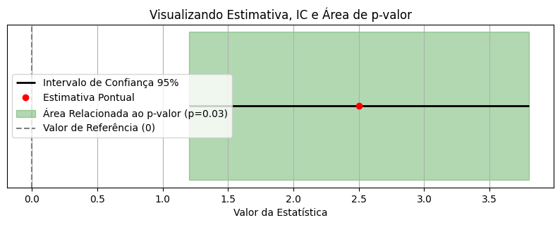

```python
# Novo gráfico baseado no seu pedido:
# Mostrar valor-p como uma faixa, com estimativa pontual e intervalo de confiança

# Configurações
p_value = 0.03  # valor-p hipotético (significativo)
estimate = 2.5  # estimativa pontual
ci_lower = 1.2  # limite inferior do IC
ci_upper = 3.8  # limite superior do IC

# Criar o gráfico
plt.figure(figsize=(10, 3))

# Desenhar a linha do intervalo de confiança
plt.hlines(1, ci_lower, ci_upper, color='black', linewidth=2, label='Intervalo de Confiança 95%')

# Marcar a estimativa pontual
plt.plot(estimate, 1, 'o', color='red', label='Estimativa Pontual')

# Adicionar faixa ilustrando o p-valor
plt.fill_betweenx([0.9, 1.1], ci_lower, ci_upper, color='green', alpha=0.3, label=f'Área Relacionada ao p-valor (p={p_value})')

# Ajustes visuais
plt.axvline(x=0, color='gray', linestyle='--', label='Valor de Referência (0)')
plt.yticks([])
plt.xlabel('Valor da Estatística')
plt.title('Visualizando Estimativa, IC e Área de p-valor')
plt.legend()
plt.grid(True)
plt.show()
```

- Linha preta: é o Intervalo de Confiança (IC 95%) — vai de 1.2 a 3.8.
- Ponto vermelho: é a Estimativa Pontual (neste exemplo, 2.5).
- Área verde clara: representa a região associada ao p-valor.
- Linha tracejada no 0: é o valor de referência da hipótese nula H0 (sem efeito).

📊 Interpretação:

- Como o intervalo não inclui o 0, rejeitamos H0.
- A estimativa pontual está centralizada dentro do intervalo de confiança.
- O p-valor de 0,03 confirma essa rejeição para um nível de 𝛼 = 0,05

# 🧠 Exemplo para ilustrar

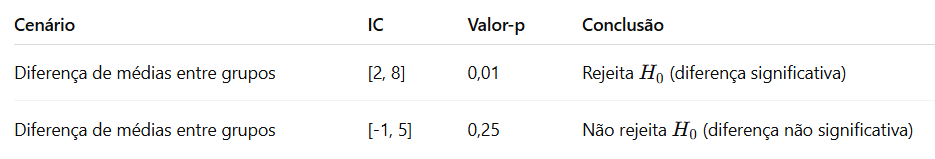

# 📚 Detalhe importante

- Para diferenças absolutas (ex: médias, proporções): o valor crítico é 0.
- Para indicadores relativos (ex: risco relativo, odds ratio): o valor crítico é 1.

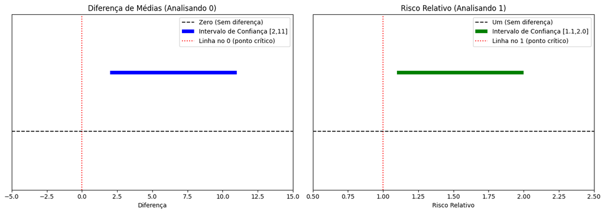

```python
import matplotlib.pyplot as plt

# Criar uma figura com dois gráficos lado a lado
fig, axs = plt.subplots(1, 2, figsize=(14, 5))

# Gráfico 1: Diferença de médias (analisando 0)
axs[0].hlines(0, -5, 15, colors='black', linestyles='--', label='Zero (Sem diferença)')
axs[0].hlines(1, 2, 11, colors='blue', linewidth=6, label='Intervalo de Confiança [2,11]')
axs[0].vlines(0, -1, 2, colors='red', linestyles=':', label='Linha no 0 (ponto crítico)')
axs[0].set_xlim(-5, 15)
axs[0].set_ylim(-1, 2)
axs[0].set_title('Diferença de Médias (Analisando 0)')
axs[0].set_xlabel('Diferença')
axs[0].set_yticks([])
axs[0].legend(loc='upper right')

# Gráfico 2: Risco Relativo (analisando 1)
axs[1].hlines(1, 0.5, 2.5, colors='black', linestyles='--', label='Um (Sem diferença)')
axs[1].hlines(1.2, 1.1, 2.0, colors='green', linewidth=6, label='Intervalo de Confiança [1.1,2.0]')
axs[1].vlines(1, 0.8, 1.4, colors='red', linestyles=':', label='Linha no 1 (ponto crítico)')
axs[1].set_xlim(0.5, 2.5)
axs[1].set_ylim(0.8, 1.4)
axs[1].set_title('Risco Relativo (Analisando 1)')
axs[1].set_xlabel('Risco Relativo')
axs[1].set_yticks([])
axs[1].legend(loc='upper right')

plt.tight_layout()
plt.show()
```